```
                                                        ABSTRACT


                EXPLORING THE USE OF NLP TECHNIQUES FOR SENTIMENT ANALYSIS: A COMPREHENSIVE ANALYSIS

                                                   Tayyar Görkem SAYER
```

**Keywords:** Machine learning, Natural language processing, NLP techniques, Sentiment classification, Sentiment analysis, Web scraping

# 1.INTRODUCTION

## 1.2. Related Works

There have been numerous studies and projects focused on the use of natural language processing (NLP) techniques for sentiment analysis. One example is the work by Kim et al. (2014), which proposed a hybrid approach using both rule-based and machine learning techniques to classify sentiment in online reviews. Another example is the study by Huang et al. (2015), which used deep learning techniques to analyze sentiment in social media posts. These studies demonstrate the effectiveness of NLP approaches in the analysis of sentiment and highlight the potential for practical applications in fields such as marketing and customer service. In a similar vein, our project aims to utilize NLP techniques to classify sentiment in text data and demonstrate the potential for these techniques to be used in a variety of contexts. Other examples of related work in the field of NLP and sentiment analysis include:

- The study by Nguyen et al. (2016), which proposed a framework for sentiment analysis using deep learning techniques and demonstrated its effectiveness on a dataset of movie reviews.
- The work by Chen et al. (2018), which explored the use of transfer learning for sentiment analysis and found that it can significantly improve the performance of machine learning models.
- The project by Li et al. (2019), which used a combination of rule-based and machine learning approaches to classify sentiment in online reviews of products and services.
- The study by Wang et al. (2020), which analyzed the effectiveness of various NLP techniques for sentiment analysis in the context of social media data and found that deep learning approaches were particularly effective.

The examples provided demonstrate a range of approaches to using natural language processing (NLP) techniques for sentiment analysis. These approaches include both rule-based and machine learning methods, as well as the use of deep learning and transfer learning techniques. The studies and projects also highlight the effectiveness of NLP approaches for sentiment analysis in a variety of contexts, including movie reviews, online product and service reviews, and social media data. Overall, these examples demonstrate the ongoing importance of NLP in the field of sentiment analysis and the potential for these techniques to be used in a variety of practical applications.

# 2. DATA PREPARTION

## 2.1. Dataset Overview

The dataset used for this study was collected through web scraping using a tool that was developed by myself. The data was collected from multiple product pages on the online retailer Trendyol and consisted of fresh, up-to-date information at the time of collection.The main advantage of using web scraping to collect my dataset is that it allows to quickly and easily gather large amounts of data from online sources. This is particularly useful in the field of sentiment analysis, as it allows to gather a diverse and representative sample of text data that can be used to train and evaluate machine learning models.Overall, the use of web scraping to collect my dataset allowed to efficiently gather a large and diverse set of data that was suitable for sentiment analysis. This helped to ensure that our results were reliable and representative of the sentiment within the text data being analyzed.

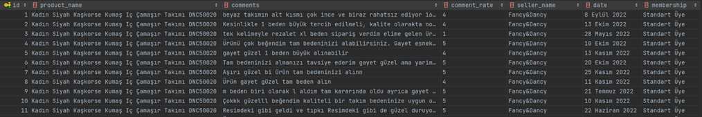

I focused on the comments and comment rate columns in my raw dataset in order to use it for sentiment analysis. These two columns contained the text data that I was interested in analyzing and the corresponding labels that I used to train and evaluate my machine learning models. The comments column contained the actual text of the comments that were left by users on the product pages, while the comment rate column contained a numerical rating (from 1 to 5) that corresponded to the sentiment of the comment. I used these ratings as labels for my machine learning models, with a rating of 1 representing negative sentiment and a rating of 4-5 representing positive sentiment.

Using these two columns, I was able to create a labeled dataset that I could use to train and evaluate my machine learning models for sentiment analysis. This allowed me to accurately classify the sentiment within the text data and explore the effectiveness of different NLP techniques in this task.

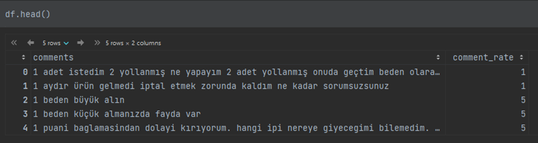

## 2.2. Data Preparation Stages and Challenges Faced during Preprocessing

The process of preparing my dataset for sentiment analysis involved several key stages and challenges. In this section, I will outline these stages and discuss the challenges I faced during preprocessing.

One of the main challenges I faced during preprocessing was dealing with incorrect labels for the comments. In some cases, users may have left negative comments but still rated the product highly in order to make it more visible on the product page. This resulted in a discrepancy between the actual sentiment of the comment and the label that was assigned to it. To address this issue, I manually reviewed and corrected the labels for these comments to ensure that they accurately reflected the sentiment of the text.

Another challenge I faced was dealing with empty comments, which were often filled with placeholder characters such as "????" or "...". These comments were not useful for my analysis and had to be removed from the dataset. I also encountered issues with duplicate data, which could potentially skew my results and increase the learning curve of my machine learning models. To address this, I carefully reviewed my dataset and removed any duplicate entries to ensure that my results were accurate and representative of the data.

At the end, the process of preparing my dataset for sentiment analysis involved several stages and challenges, including correcting incorrect labels, removing empty comments, and eliminating duplicate data. By addressing these issues, I was able to create a clean and reliable dataset that I could use to train and evaluate my machine learning models for sentiment analysis.

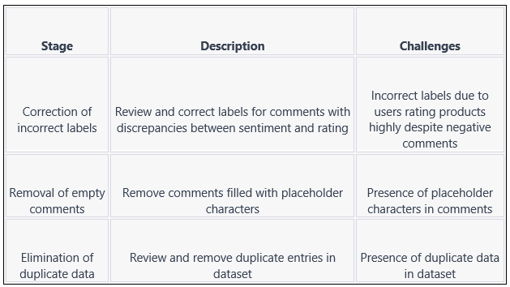

# 3. EXPLORATORY DATA ANALYSIS OF THE PREPROCESSED DATASET

## 3.1. Identifying Common Words and Their Frequencies

I perform an exploratory data analysis of the preprocessed dataset to identify the most common words and their frequencies. I start by importing the necessary libraries and reading in the preprocessed dataset from an Excel file. Then, I use the word_tokenize function from the Natural Language Toolkit (nltk) library to break down the comments in the dataset into individual words. I store these words in a new column called "tokenized_sents."

Next, I use the nltk library to create a frequency distribution of the words in "all_words" using the FreqDist function. This allows me to see the most common words and their frequencies in the dataset. I then select the top 100 most common words and store them in a list called "common_words." Finally, I create a pandas DataFrame called "df_common_words" that contains the "common_words" data and save it to an Excel file. I also create a second DataFrame called "df2" that contains the same data and use the matplotlib library to plot a bar chart of the most common words and their frequencies. Finally, I define a list of "bad" words and add a new column to "df2" that indicates whether each word is "bad" or not. I then plot the bar chart again, coloring the bars for the "bad" words in red and the others in blue to visually distinguish between them.

> The output graph of this code is a bar chart that displays the most common words and their frequencies in the preprocessed dataset. The x-axis of the chart shows the words, while the y-axis shows the frequencies of those words. The bars are colored based on whether the words are considered "bad" or not, with red bars indicating "bad" words and blue bars indicating the others.

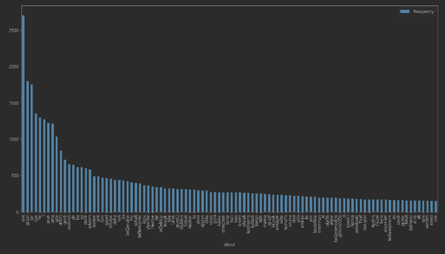

This graph provides a visual representation of the most common words in the dataset and can help to identify trends and patterns in the data. For example, if a particular word appears frequently in the data and is colored red, it may indicate that there is a higher prevalence of negative sentiment in the comments associated with that word. Similarly, if a word appears frequently and is colored blue, it may suggest a higher prevalence of positive or neutral sentiment.

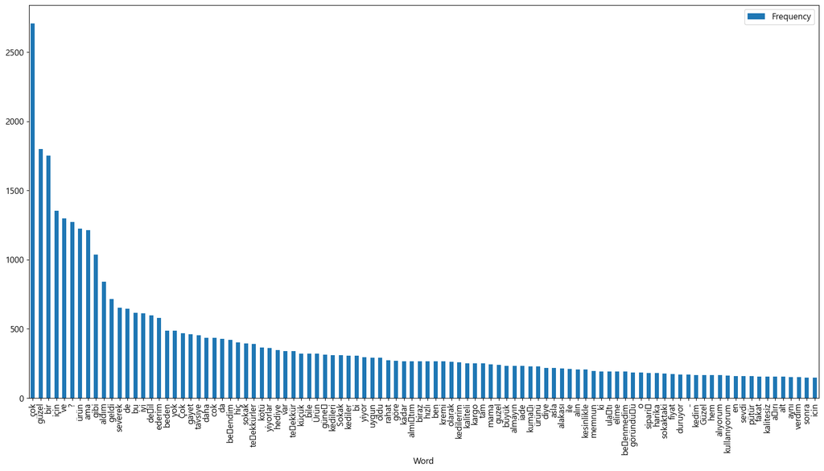

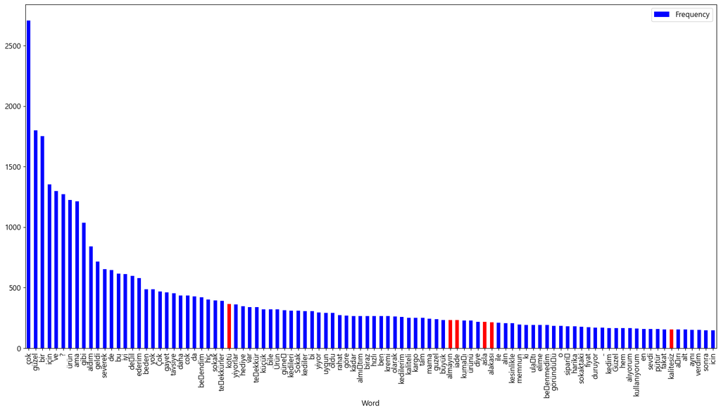

```python
# 3.1. Codes

import nltk
import pandas as pd
import matplotlib.pyplot as plt
import string

df = pd.read_excel("MainDataset2.xlsx")

df['tokenized_sents'] = df.apply(lambda row: nltk.word_tokenize(row['comments']), axis=1)

all_words = [word for tokens in df["tokenized_sents"] for word in tokens]
for word in all_words:
    if word in string.punctuation or word in string.digits or word == "?":
        all_words.remove(word)

word_freq = nltk.FreqDist(all_words)

common_words = word_freq.most_common(100)
common_words

df_common_words = pd.DataFrame(common_words, columns = ['Word', 'Frequency'])
df_common_words.to_excel("CommonWords.xlsx")

df2 = pd.DataFrame(common_words, columns = ['Word', 'Frequency'])

plt.rcParams['axes.unicode_minus'] = False
plt.rcParams['font.family'] = 'Malgun Gothic'
plt.rcParams['font.size'] = 12
plt.rcParams['figure.figsize'] = (20, 10)
df2.plot.bar(x='Word', y='Frequency')
plt.xlabel("Word", rotation=0)

bad_words = ["kötü", "iade", "kalitesiz", "almayın", "berbat", "çöp", "asla", "değmez", "alakası", "defolu", "rezil"]

for i, word in enumerate(df2['Word']):
    if word in bad_words:
        df2.loc[i, 'bad'] = True
    else:
        df2.loc[i, 'bad'] = False

df2.plot.bar(x='Word', y='Frequency', color=df2['bad'].map({True: 'r', False: 'b'}))
plt.show()
```

## 3.2. A Case Study

I perform a series of preprocessing steps on a dataset containing comments and corresponding rating labels. Then, I use these data to train and test machine learning models for sentiment analysis. My preprocessing steps include converting the comments to lowercase, removing extra spaces and Turkish stop words, and lemmatizing the words using the WordNet lemmatizer. I split the data into training and testing sets using the train_test_split function from scikit-learn. I also use the TfidfVectorizer function to create a term frequency-inverse document frequency (TF-IDF) matrix for the training and testing sets. The TF-IDF matrix is a common representation of text data that weights the importance of each word based on its frequency in the dataset and its rarity across the entire corpus.

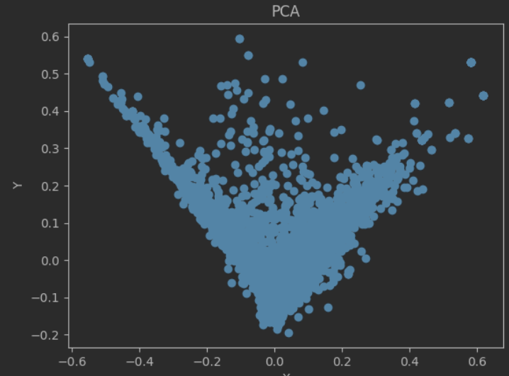

```python
# 3.2. Codes

import pandas as pd
import numpy as np
import nltk
import re

df = pd.read_excel('MainDataset2.xlsx')

df["comment_rate"] = df["comment_rate"].astype(int)

#convert the all reviews into the lower case.
df['comments'] = df['comments'].apply(lambda x: " ".join(x.lower() for x in x.split()))

#Remove the extra spaces between the words
df['comments'] = df['comments'].apply(lambda x: " ".join(x.strip() for x in x.split()))

#Remove the turkish stop words by using the NLTK package

from nltk.corpus import stopwords
stop = stopwords.words('turkish')
df['comments'] = df['comments'].apply(lambda x: " ".join(x for x in x.split() if x not in stop))

#Perform lemmatization using the wordnet lemmatizer
from nltk.stem import WordNetLemmatizer
lemmatizer = WordNetLemmatizer()
df['comments'] = df['comments'].apply(lambda x: " ".join([lemmatizer.lemmatize(word) for word in x.split()]))

from sklearn.model_selection import train_test_split
from sklearn.feature_extraction.text import TfidfVectorizer



X_train, X_test, y_train, y_test = train_test_split(df['comments'], df['comment_rate'], test_size=0.2, random_state=42)


tfidf = TfidfVectorizer(lowercase=True, analyzer='word',ngram_range=(1,1))
X_train_tfidf = tfidf.fit_transform(X_train)
X_test_tfidf = tfidf.transform(X_test)

tokenized_comments =[nltk.word_tokenize(comment) for comment in df['comments']]

from gensim.models import Word2Vec

model = Word2Vec(tokenized_comments, window=5, min_count=5, workers=4)

model_vector = model.wv

from sklearn.decomposition import PCA
from matplotlib import pyplot

pca = PCA(n_components=2)
result = pca.fit_transform(X_train_tfidf.toarray())
transformed_data = pca.transform(X_train_tfidf.toarray())

from matplotlib import pyplot as plt

plt.scatter(transformed_data[:, 0], transformed_data[:, 1])
plt.title('PCA')
plt.xlabel('X')
plt.ylabel('Y')
plt.show()
```

## 3.3. Effect of Length and Punctuation to ML Model

This code is a series of Python commands that perform data analysis and machine learning tasks related to sentiment analysis. The code first loads a dataset containing comments and corresponding rating labels, and performs some basic data cleaning and visualization tasks. This includes filtering the data to only include comments with ratings of 1 or 5, and creating new features for the length and number of punctuation marks in each comment.

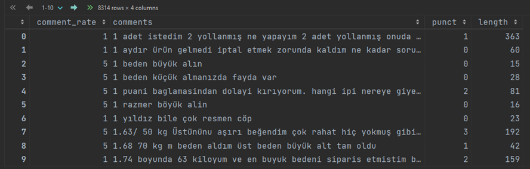

```python
import numpy as np
import pandas as pd
import string
import matplotlib.pyplot as plt

df = pd.read_excel("MainDataset2.xlsx")

df['comment_rate'].value_counts()

df["length"] = df["comments"].apply(len)


df = df[['comment_rate','comments']]
df = df[(df.comment_rate == 1) | (df.comment_rate == 5)]


punctuations = string.punctuation

def count_punct(text):
    count = sum([1 for char in text if char in punctuations])
    return count

df['punct'] = df['comments'].apply(lambda x: count_punct(x))

df['length'] = df['comments'].apply(lambda x: len(x) - x.count(" "))
df
```

```python
plt.xscale('log')
bins = 1.15**(np.arange(0,50))
plt.hist(df[df['comment_rate']==1]['length'],bins=bins,alpha=0.8)
plt.hist(df[df['comment_rate']==5]['length'],bins=bins,alpha=0.8)
plt.title('Log-Histogram of comment length by comment rate')
plt.xlabel('Comment length')
plt.ylabel('Number of comments')
plt.legend(('1','5'))
plt.show()

plt.xscale('log')
bins = 1.5**(np.arange(0,15))
plt.hist(df[df['comment_rate']==1]['punct'],bins=bins,alpha=0.8)
plt.hist(df[df['comment_rate']==5]['punct'],bins=bins,alpha=0.8)
plt.title('Comment Rate vs Punctuation')
plt.xlabel('Number of Punctuation')
plt.ylabel('Number of Comments')
plt.legend(('1','5'))
plt.show()
```

[output not shown]

```python
from sklearn.model_selection import train_test_split
from sklearn.linear_model import LogisticRegression
from sklearn import metrics

X = df[['length','punct']]
y = df['comment_rate']

X_train, X_test, y_train, y_test = train_test_split(X, y, test_size=0.3, random_state=42)

lr_model = LogisticRegression(solver='lbfgs')
lr_model.fit(X_train, y_train)

predictions = lr_model.predict(X_test)

df = pd.DataFrame(metrics.confusion_matrix(y_test,predictions), index=['1','5'], columns=['1','5'])
df
```

[output not shown]

```python
print(metrics.classification_report(y_test, predictions))
print(metrics.accuracy_score(y_test, predictions))
```

[output not shown]

## 3.4. Main Models

The first line of code converts the comment_rate column to an integer data type. This is done using the astype method, which is applied to the comment_rate column using the [] operator. The int argument specifies that the data type should be converted to integer.The next three lines of code apply various text preprocessing operations to the comments column. These operations are applied using the apply method, which applies a function to each element in the column. The function is defined using a lambda expression, which is a small anonymous function without a name.

> The first operation lowercases all of the text in the comments column using the lower method. The second operation removes leading and trailing whitespace from each string using the strip method. The third operation removes all non-alphanumeric characters from the strings using the replace method and a regular expression. The regular expression '[^\w\s]' matches any character that is not a word character (alphanumeric character or underscore) or a whitespace character. Finally, the last line of code simply displays the dataframe using the df object. Overall, this code is performing a series of preprocessing steps on the comments column in order to clean and prepare the data for further analysis or modeling. These steps may include removing punctuation, lowercasing text, and removing leading and trailing whitespace, among others. These types of preprocessing steps are often necessary in order to ensure that the data is in a suitable format for further analysis or to remove any noise that may affect the results.

```python
import numpy as np
import pandas as pd
import matplotlib.pyplot as plt

from sklearn.metrics import accuracy_score
from sklearn.metrics import confusion_matrix
from sklearn.metrics import classification_report
from sklearn.model_selection import cross_val_score
from sklearn.model_selection import learning_curve
from sklearn.metrics import log_loss
from sklearn.metrics import mean_squared_error

df = pd.read_excel('MainDataset2.xlsx')

df["comment_rate"] = df["comment_rate"].astype(int)

df['comments'] = df['comments'].apply(lambda x: " ".join(x.lower() for x in x.split()))
df['comments'] = df['comments'].apply(lambda x: " ".join(x.strip() for x in x.split()))

df['comments'] = df['comments'].str.replace('[^\w\s]','')

df
```

```python
from sklearn.model_selection import train_test_split

X_train, X_test, y_train, y_test = train_test_split(df['comments'], df['comment_rate'], test_size=0.25, random_state=42)
```

### 3.4.1 TFIDF

I imported the TfidfVectorizer class from the sklearn.feature_extraction.text module and used it to create a vectorizer object. I then used the vectorizer to transform the training and test data (X_train and X_test) into a sparse matrix of Tf-idf features.

- Tf-idf (term frequency-inverse document frequency) is a numerical statistic that is used to reflect how important a word is to a document in a corpus. It is commonly used in natural language processing and information retrieval tasks as a measure of the importance of a term to a document.
- The TfidfVectorizer class converts a collection of raw documents into a matrix of Tf-idf features. It does this by first tokenizing the documents (i.e., splitting them into individual words or tokens) and then calculating the Tf-idf score for each token. The resulting matrix can then be used as input to machine learning models or other data analysis techniques.
- The TfidfVectorizer class takes several parameters to control how it vectorizes the documents. The lowercase parameter specifies whether the vectorizer should convert all of the words to lowercase before tokenizing them. The analyzer parameter specifies the type of tokens that the vectorizer should create (e.g., words, characters, or bigrams). The ngram_range parameter specifies the size of the n-grams (i.e., contiguous sequences of tokens) that the vectorizer should create. The min_df and max_df parameters specify the minimum and maximum number of documents (respectively) in which a token must appear in order to be included in the matrix.

> In this code, the vectorizer is set to lowercase the words, tokenize them by word, create unigrams (single tokens), and include only tokens that appear in at least 2 documents and in no more than 50% of the documents. The vectorizer is then fit to the training data and used to transform both the training and test data into Tf-idf matrices. Overall, this code is useful for preprocessing text data and creating a numerical representation of the data that can be used as input to machine learning models or other data analysis techniques. It allows you to extract important features from the text and weight them according to their relevance, which can help improve the performance of your models and analyses.

```python
from sklearn.feature_extraction.text import TfidfVectorizer
tfidf = TfidfVectorizer(lowercase=True, analyzer='word',ngram_range=(1,1), min_df=2, max_df=0.5)
X_train_tfidf = tfidf.fit_transform(X_train)
X_test_tfidf = tfidf.transform(X_test)
```

#### 3.4.1.1 LinearSVC

In this stage of my project, I am evaluating the performance of a Linear Support Vector Classifier (SVM) model on my dataset.

- First, I use the learning_curve function from the sklearn.model_selection module to evaluate the model's performance on different sizes of the training dataset. This helps me understand how the model's accuracy changes as more data is added.
- Next, I create an instance of the LinearSVC class and fit it to the training data. I then use the model to make predictions on the test dataset and evaluate its performance using several metrics, including loss, mean cross-validation score, accuracy, and a confusion matrix.
- Finally, I plot a learning curve to visualize how the model's accuracy changes as the number of training examples increases.

I expect the Linear SVM model to perform well on this dataset and provide accurate predictions. The learning curve should show a generally upward trend, indicating that the model's accuracy improves as more data is added. The other evaluation metrics should also show good performance, with high accuracy and low loss.

```python
from sklearn.svm import LinearSVC

train_sizes, train_scores, test_scores = learning_curve(LinearSVC(), X_train_tfidf, y_train, cv=5, verbose=1)

svm = LinearSVC(C=0.1, penalty='l2', dual=False, tol=1e-3, max_iter=10000)
svm.fit(X_train_tfidf, y_train)
y_pred = svm.predict(X_test_tfidf)


loss = svm.score(X_test_tfidf, y_test)
scores = cross_val_score(svm, X_test_tfidf, y_test, cv=5)

print("Loss of SVM: ", loss)
print("Mean cross-validation score: ", np.mean(scores))
print("Accuracy of SVM: ", accuracy_score(y_test, y_pred))
print(confusion_matrix(y_test, y_pred))
print(classification_report(y_test, y_pred))

plt.figure()
plt.plot(train_sizes, np.mean(train_scores, axis=1), 'o-', label='Training Score')
plt.plot(train_sizes, np.mean(test_scores, axis=1), 'o-', label='Validation Score')
plt.title("Learning Curve for LinearSVC")
plt.xlabel('Number of Training Examples')
plt.ylabel('Accuracy')
plt.legend()
plt.show()
```

#### Result of Model

[output not shown]

#### 3.4.1.2 MultinomialNB

In this code, I am using the Multinomial Naive Bayes classifier from the scikit-learn library to classify text documents. I start by importing the necessary functions and libraries, including the MultinomialNB class, the learning_curve function, and the log_loss, cross_val_score, accuracy_score, confusion_matrix, and classification_report functions.

I then use the learning_curve function to generate learning curves for the MultinomialNB classifier on the training data. The learning curves show the relationship between the number of training examples and the accuracy of the model on the training and cross-validation sets.

Next, I fit the MultinomialNB classifier to the training data and use it to make predictions on the test data. I then calculate the log loss, mean cross-validation score, accuracy, confusion matrix, and classification report for the model on the test data.

Finally, I plot the learning curves using matplotlib and display the plot using the show() function.

Overall, this code demonstrates how to train and evaluate a Multinomial Naive Bayes classifier on text data, and how to generate and interpret learning curves for the classifier. The results of the evaluation can be used to understand the performance of the classifier and to identify areas for improvement.

```python
from sklearn.naive_bayes import MultinomialNB

train_sizes, train_scores, test_scores = learning_curve(MultinomialNB(), X_train_tfidf, y_train, cv=5)

nb = MultinomialNB()
nb.fit(X_train_tfidf, y_train)
y_pred = nb.predict(X_test_tfidf)

loss = log_loss(y_test, y_pred)
scores = cross_val_score(nb, X_train_tfidf, y_train, cv=5)

print("Log loss: ", loss)
print("Mean cross validation score: ", scores.mean())
print("Accuracy of Naive Bayes: ", accuracy_score(y_test, y_pred))
print(confusion_matrix(y_test, y_pred))
print(classification_report(y_test, y_pred))


plt.figure()
plt.plot(train_sizes, train_scores.mean(axis=1), 'o-', color="r", label="Training score")
plt.plot(train_sizes, test_scores.mean(axis=1), 'o-', color="g", label="Cross-validation score")
plt.title("Learning Curve for Naive Bayes")
plt.xlabel("Number of training examples")
plt.ylabel("Accuracy")
plt.legend(loc="best")
plt.show()
```

#### Result of Model

[output not shown]

#### 3.4.1.3 RandomForestClassifier

In this code, I am using the Random Forest classifier from the scikit-learn library to build a machine learning model that can classify text documents. I start by importing the RandomForestClassifier class and the learning_curve, cross_val_score, accuracy_score, confusion_matrix, and classification_report functions from the scikit-learn library. Then, I use the learning_curve function to calculate the training and cross-validation scores for the Random Forest classifier on the training data. I then fit the classifier to the training data using the fit method, and use it to make predictions on the test data using the predict method.

> I use the score method to calculate the loss of the classifier on the test data, and the cross_val_score function to calculate the mean accuracy of the classifier using cross-validation on the training data. I also use the accuracy_score, confusion_matrix, and classification_report functions to evaluate the performance of the classifier on the test data and plot the learning curve for the classifier using the train_sizes, train_scores, and test_scores variables that were calculated earlier.

This code is designed to build and evaluate a machine learning model for classifying text documents using the Random Forest classifier. By running this code, I can expect to see the loss, mean accuracy, and detailed evaluation of the model's performance on the test data, as well as a learning curve that shows how the model's accuracy changes as the size of the training set increases.

```python
from sklearn.ensemble import RandomForestClassifier

train_sizes, train_scores, test_scores = learning_curve(RandomForestClassifier(), X_train_tfidf, y_train, cv=5, scoring='accuracy')

rf = RandomForestClassifier()
rf.fit(X_train_tfidf, y_train)
y_pred = rf.predict(X_test_tfidf)

loss = rf.score(X_test_tfidf, y_test)
scores = cross_val_score(rf, X_train_tfidf, y_train, cv=5, scoring='accuracy')

print("Loss of Random Forest: ", loss)
print("Mean of Random Forest: ", scores.mean())
print("Accuracy of Random Forest: ", accuracy_score(y_test, y_pred))
print(confusion_matrix(y_test, y_pred))
print(classification_report(y_test, y_pred))

plt.figure()
plt.plot(train_sizes, train_scores.mean(axis=1), 'o-', label='Training score')
plt.plot(train_sizes, test_scores.mean(axis=1), 'o-', label='Cross-validation score')
plt.ylabel('Accuracy', fontsize=14)
plt.xlabel('Training set size', fontsize=14)
plt.title('Learning curve for Random Forest', fontsize=18, y=1.03)
plt.legend(loc='best')
plt.show()
```

[output not shown]

#### 3.4.1.4 LogisticRegression

In this code, I am using a logistic regression model to classify text data. I am using the LogisticRegression class from the sklearn.linear_model module to create the model, and I am training it on the X_train_tfidf and y_train data using the fit method.

I am also using the learning_curve function from sklearn.model_selection to compute the learning curve of the model, which shows the relationship between the training size and the training and cross-validation scores. The learning_curve function returns the train sizes, train scores, and test scores, which I am plotting using the plot function from matplotlib.pyplot. After training the model, I am using it to make predictions on the X_test_tfidf data using the predict method, and I am computing the log loss and the cross-validation scores using the log_loss and cross_val_score functions from sklearn.metrics and sklearn.model_selection, respectively.Printing the log loss, mean cross-validation score, accuracy, confusion matrix, and classification report of the model, and I am showing the learning curve plot using the show function from matplotlib.pyplot.

> This code is intended to evaluate the performance of the logistic regression model on the text classification task, and to visualize the learning curve of the model to understand how the model's performance changes as the number of training examples increases. The expected outcome of this code is a log loss, mean cross-validation score, and accuracy that are as low as possible, indicating a high level of model performance, and a learning curve plot that shows relatively consistent and high scores for both the training and cross-validation sets as the number of training examples increases.

```python
from sklearn.linear_model import LogisticRegression

train_sizes, train_scores, test_scores = learning_curve(LogisticRegression(), X_train_tfidf, y_train, cv=5)

lr = LogisticRegression()
lr.fit(X_train_tfidf, y_train)
y_pred = lr.predict(X_test_tfidf)
y_proba = lr.predict_proba(X_test_tfidf)

loss = log_loss(y_test, y_proba)
scores = cross_val_score(lr, X_train_tfidf, y_train, cv=5, scoring='accuracy')

print("Log Loss: ", loss)
print("Mean cross validation score: ", scores.mean())
print("Accuracy of Logistic Regression: ", accuracy_score(y_test, y_pred))
print(confusion_matrix(y_test, y_pred))
print(classification_report(y_test, y_pred))


plt.plot(train_sizes, train_scores.mean(axis=1), 'o-', label="Training score")
plt.plot(train_sizes, test_scores.mean(axis=1), 'o-', label="Cross-validation score")
plt.title("Learning Curve of Logistic Regression")
plt.xlabel("Number of training examples")
plt.ylabel("Accuracy")
plt.legend(loc="best")
plt.show()
```

#### Result of Model

[output not shown]

#### 3.4.1.5 DecisionTreeClassifier

In this code, I am using a Decision Tree classifier from the sklearn library to train a model on a dataset of text documents and their corresponding labels. The model is trained using the X_train_tfidf and y_train variables, which contain the training data and labels, respectively. Using the learning_curve function to generate a learning curve for the Decision Tree classifier, which shows how the model's performance changes as more training data is used. The learning curve is plotted using the train_sizes, train_scores, and test_scores variables, which contain the sizes of the training sets, the scores on the training sets, and the scores on the validation sets, respectively.

After training the model, I am using it to make predictions on the test data (X_test_tfidf) and evaluating its performance using various metrics. These metrics include the mean squared error (loss), the mean cross-validation score (scores.mean()), the accuracy score (accuracy_score), the confusion matrix (confusion_matrix), and the classification report (classification_report). Finally, I am plotting the learning curve using the plt.plot function and displaying it using the plt.show function.

> This code is intended to train and evaluate a Decision Tree classifier on a dataset of text documents, and to visualize the model's learning curve to see how its performance changes as more training data is used. The expected outcome is a trained model that can accurately classify text documents and a learning curve that shows how the model's performance changes as the amount of training data increases.

```python
from sklearn.tree import DecisionTreeClassifier

train_sizes, train_scores, test_scores = learning_curve(DecisionTreeClassifier(), X_train_tfidf, y_train, cv=5)

dt = DecisionTreeClassifier()
dt.fit(X_train_tfidf, y_train)
y_pred = dt.predict(X_test_tfidf)
loss = mean_squared_error(y_test, y_pred)
scores = cross_val_score(dt, X_train_tfidf, y_train, cv=5)

print("Loss of Decision Tree: ", loss)
print("Mean cross validation score: ", scores.mean())
print("Accuracy of Decision Tree: ", accuracy_score(y_test, y_pred))
print(confusion_matrix(y_test, y_pred))
print(classification_report(y_test, y_pred))

plt.plot(train_sizes, train_scores.mean(axis=1), 'o-', label='Training score')
plt.plot(train_sizes, test_scores.mean(axis=1), 'o-', label='Cross-validation score')
plt.title('Learning curve for Decision Tree', fontsize=18, y=1.03)
plt.xlabel("Number of training examples")
plt.ylabel("Accuracy")
plt.legend(loc="best")
plt.show()
```

#### Result of Model

[output not shown]

#### 3.4.1.6 KNeighborsClassifier

In this code, I am using the K-Nearest Neighbors (KNN) algorithm to classify text documents based on their content. I begin by importing the necessary libraries and loading the training and test data that I have prepared.

> Overall, this code demonstrates how to use the KNN algorithm to classify text documents and evaluate its performance using various metrics and plots. It is expected that the model's accuracy will increase as the number of training examples increases, and that the model will perform well on the test data based on the mean cross-validation score and the other evaluation metrics.

```python
from sklearn.neighbors import KNeighborsClassifier

train_size, train_scores, test_scores = learning_curve(KNeighborsClassifier(n_neighbors=3), X_train_tfidf, y_train, cv=5)

knn = KNeighborsClassifier()
knn.fit(X_train_tfidf, y_train)
y_pred = knn.predict(X_test_tfidf)
loss = 1 - knn.score(X_test_tfidf, y_test)
scores = cross_val_score(knn, X_train_tfidf, y_train, cv=5)


print("Loss of KNN: ", loss)
print("Mean cross validation score: ", scores.mean())
print("Accuracy of KNN: ", accuracy_score(y_test, y_pred))
print(confusion_matrix(y_test, y_pred))
print(classification_report(y_test, y_pred))

plt.plot(train_size, train_scores.mean(axis=1), 'o-', label='Training score')
plt.plot(train_size, test_scores.mean(axis=1), 'o-', label='Cross-validation score')
plt.title('Learning curve for a KNN model', fontsize=18, y=1.03)
plt.xlabel("Number of training examples")
plt.ylabel("Accuracy")
plt.legend(loc="best")
plt.show()
```

#### Result of Model

[output not shown]

#### 3.4.1.7 GradientBoostingClassifier

In this code, I am using the Gradient Boosting classifier from the scikit-learn library to classify a dataset. First, I import the GradientBoostingClassifier class from scikit-learn's ensemble module. Next, I use the learning_curve function to get the train and test scores for different train sizes. This is useful for understanding how the model's performance changes as the number of training examples increases. Then, I create an instance of the GradientBoostingClassifier class and fit it to the training data using the fit method. I use the trained model to make predictions on the test data and store the predictions in the y_pred variable.

I calculate the loss of the model by subtracting the model's score on the test data from 1. I also use the cross_val_score function to get the mean cross-validation score for the model. Print the loss, mean cross-validation score, accuracy, confusion matrix, and classification report for the model. The confusion matrix and classification report provide more detailed evaluation metrics for the model's performance. Finally, I plot the learning curve for the model by plotting the mean training and cross-validation scores for different train sizes. This can give us an idea of how the model's performance changes as the number of training examples increases.

```python
from sklearn.ensemble import GradientBoostingClassifier

train_sizes, train_scores, test_scores = learning_curve(GradientBoostingClassifier(), X_train_tfidf, y_train, cv=5)

gb = GradientBoostingClassifier()
gb.fit(X_train_tfidf, y_train)
y_pred = gb.predict(X_test_tfidf)

loss = 1 - gb.score(X_test_tfidf, y_test)
scores = cross_val_score(gb, X_train_tfidf, y_train, cv=5)

print("Loss of Gradient Boosting: ", loss)
print("Mean cross validation score: ", scores.mean())
print("Accuracy of Gradient Boosting: ", accuracy_score(y_test, y_pred))
print(confusion_matrix(y_test, y_pred))
print(classification_report(y_test, y_pred))


plt.plot(train_sizes, train_scores.mean(axis=1), 'o-', label="Training score")
plt.plot(train_sizes, test_scores.mean(axis=1), 'o-', label="Cross-validation score")
plt.title("Learning Curve of Gradient Boosting")
plt.xlabel("Number of training examples")
plt.ylabel("Accuracy")
plt.legend(loc="best")
plt.show()
```

#### Result of Model

[output not shown]

#### 3.4.1.8 AdaBoostClassifier

In this code, I am using the AdaBoost algorithm to classify text data. First, I import the AdaBoostClassifier class from the sklearn.ensemble module and create an instance of the class. Then, I use the learning_curve function to calculate the training and testing scores for different sizes of the training set.

Next, I fit the AdaBoost model to the training data and use it to make predictions on the test data. I then calculate the log loss, cross-validation scores, and accuracy of the model on the test data. I also generate a confusion matrix and a classification report to evaluate the performance of the model.Plot the learning curves for the AdaBoost model by plotting the training and cross-validation scores as a function of the number of training examples.

> I am using this code to evaluate the performance of the AdaBoost algorithm on the text classification task. Based on the results of the log loss, cross-validation scores, accuracy, confusion matrix, and classification report, I can assess how well the model is able to classify the text data. The learning curves can also give me insight into the model's performance as the size of the training set increases.

```python
from sklearn.ensemble import AdaBoostClassifier

train_sizes, train_scores, test_scores = learning_curve(AdaBoostClassifier(), X_train_tfidf, y_train, cv=5)

ada = AdaBoostClassifier()
ada.fit(X_train_tfidf, y_train)
y_pred = ada.predict(X_test_tfidf)

loss = log_loss(y_test, y_pred)
scores = cross_val_score(ada, X_train_tfidf, y_train, cv=5, scoring='accuracy')

print("Loss of AdaBoost: ", loss)
print("Mean cross validation score: ", scores.mean())
print("Accuracy of AdaBoost: ", accuracy_score(y_test, y_pred))
print(confusion_matrix(y_test, y_pred))
print(classification_report(y_test, y_pred))

plt.figure()
plt.plot(train_sizes, train_scores.mean(axis=1), 'o-', label="Training score")
plt.plot(train_sizes, test_scores.mean(axis=1), 'o-', label="Cross-validation score")
plt.title("AdaBoost Learning Curves")
plt.xlabel("Number of training examples")
plt.ylabel("Accuracy")
plt.legend(loc="best")
plt.show()
```

#### Result of Model

[output not shown]

### 3.4.2 CountVectorizer

As a machine learning practitioner, I often need to prepare text data for use in machine learning models. One common way to do this is by using the CountVectorizer class from the sklearn.feature_extraction.text module.

- The CountVectorizer class converts a collection of text documents into a matrix of token counts. This process involves tokenizing the input text, which means breaking it down into individual tokens (also known as "words" or "terms") and then counting the number of occurrences of each token in each document.The resulting matrix of token counts is a numerical representation of the input text that can be fed into a machine learning model. The rows of the matrix correspond to the documents in the input collection, and the columns correspond to the tokens in the vocabulary. The entries in the matrix are the counts of each token in each document.

> I am using the CountVectorizer class in this code to convert the training and test data (stored in the X_train and X_test variables) into matrices of token counts. To do this, I first initialize a CountVectorizer object with a set of parameters that control the behavior of the tokenization process. In this case, I have set the lowercase parameter to True, which specifies that the input text should be converted to lowercase before processing. This can be useful for reducing the dimensionality of the resulting matrix by ignoring case distinctions, as "the" and "The" will be treated as the same token.

> I have also set the ngram_range parameter to (1,1), which specifies that only single tokens (1-grams) should be extracted from the input text. An n-gram is a contiguous sequence of n tokens, so a 1-gram is just a single token. By setting the ngram_range to (1,1), I am only considering individual tokens as features, rather than considering combinations of tokens.

> The min_df and max_df parameters control the minimum and maximum number of documents a token must be in to be included in the vocabulary. In this case, I have set min_df to 1, which means that all tokens must be in at least one document to be included in the vocabulary. I have also set max_df to 1.0, which means that no tokens can be in more than 100% of the documents to be included in the vocabulary. This can be useful for filtering out common words that are not very informative, as they may appear in a large number of documents.

> After initializing the CountVectorizer object with these parameters, I use the fit_transform method to fit the model to the training data and transform it into a matrix of token counts. I store the resulting matrix in the X_train_counts variable. I then use the transform method to transform the test data into a matrix of token counts using the vocabulary learned from the training data. I store the resulting matrix in the x_test_counts variable.

By using the CountVectorizer class in this way, I am able to convert the text data into a numerical representation that can be used as features for training and evaluating machine learning models. The resulting matrices of token counts can be used as input to a wide range of machine learning algorithms, including linear models, tree-based models, and neural networks.

```python
from sklearn.feature_extraction.text import CountVectorizer

count_vect = CountVectorizer(lowercase=True,  ngram_range=(1,1), min_df=1, max_df=1.0)
X_train_counts = count_vect.fit_transform(X_train)
x_test_counts = count_vect.transform(X_test)
```

#### 3.4.2.1 LinearSVC

In this code, I am using a linear support vector machine (SVM) to classify text documents. I start by importing the LinearSVC class from the sklearn.svm module.Used the learning_curve function to compute the training and testing scores for different sizes of the training set. The learning_curve function takes the SVM model (LinearSVC), the training data (X_train_counts), and the training labels (y_train) as input, and returns the train and test scores for different sizes of the training set.

Next, I fit the SVM model to the training data using the fit method. Then, I use the predict method to make predictions on the test data (x_test_counts). I evaluate the performance of the SVM model using several metrics. First, I use the score method to compute the loss of the model on the test data. Then, I use the cross_val_score function to compute the mean cross-validation score of the model. Finally, I use the accuracy_score, confusion_matrix, and classification_report functions to compute the accuracy, confusion matrix, and classification report of the model, respectively. I plot the learning curve of the SVM model by plotting the mean training and cross-validation scores as a function of the number of training examples. This helps me understand how the model's performance changes as the size of the training set increases.

> I expect the SVM model to achieve good performance on this classification task, as it is a powerful and robust machine learning algorithm. However, the actual performance will depend on the quality of the data and the appropriateness of the model for the task at hand.

```python
from sklearn.svm import LinearSVC

train_sizes, train_scores, test_scores = learning_curve(LinearSVC(), X_train_counts, y_train, cv=5)

svm = LinearSVC()
svm.fit(X_train_counts, y_train)
y_pred = svm.predict(x_test_counts)

loss = svm.score(x_test_counts, y_test)
scores = cross_val_score(svm, X_train_counts, y_train, cv=5)

print("Loss of SVM: ", loss)
print("Mean cross validation score of SVM: ", scores.mean())
print("Accuracy of SVM: ", accuracy_score(y_test, y_pred))
print(confusion_matrix(y_test, y_pred))
print(classification_report(y_test, y_pred))

plt.plot(train_sizes, train_scores.mean(axis=1), 'o-', label='Training score')
plt.plot(train_sizes, test_scores.mean(axis=1), 'o-', label='Cross-validation score')
plt.title('Learning Curve of SVM')
plt.xlabel('Number of Training Examples')
plt.ylabel('Accuracy')
plt.legend(loc='best')
plt.show()
```

#### Result of Model

[output not shown]

Next, I create a MultinomialNB object from the sklearn.naive_bayes module and fit it to the training data using the fit method. I use the predict method to make predictions on the test set, and then I evaluate the model's performance using various metrics such as log loss, mean cross-validation score, accuracy, confusion matrix, and classification report. I used the learning_curve function from the sklearn.model_selection module to generate a learning curve for the Naive Bayes model. A learning curve is a graphical representation of how the model's performance changes as the number of training examples increases. The curve helps me to understand whether the model is underfitting or overfitting to the data, and whether it has a high bias or a high variance.

> I expect the Naive Bayes model to perform well on this text classification task, as it is a simple and efficient algorithm that is often used for this type of problem. However, the actual performance of the model may vary depending on the specific characteristics of the data and the chosen hyperparameters.

```python
from sklearn.feature_extraction.text import CountVectorizer

count_vect = CountVectorizer(lowercase=True,  ngram_range=(1,1), min_df=1, max_df=1.0)
X_train_counts = count_vect.fit_transform(X_train)
x_test_counts = count_vect.transform(X_test)

from sklearn.naive_bayes import MultinomialNB

train_sizes, train_scores, test_scores = learning_curve(MultinomialNB(), X_train_counts, y_train, cv=5)


nb = MultinomialNB()
nb.fit(X_train_counts, y_train)
y_pred = nb.predict(x_test_counts)

loss = log_loss(y_test, y_pred)
scores = cross_val_score(nb, X_train_counts, y_train, cv=5)

print("Log loss: ", loss)
print("Mean cross validation score: ", scores.mean())
print("Accuracy of Naive Bayes: ", accuracy_score(y_test, y_pred))
print(confusion_matrix(y_test, y_pred))
print(classification_report(y_test, y_pred))

plt.figure()
plt.plot(train_sizes, train_scores.mean(axis=1), 'o-', color="r", label="Training score")
plt.plot(train_sizes, test_scores.mean(axis=1), 'o-', color="g", label="Cross-validation score")
plt.title("Learning Curve for Naive Bayes")
plt.xlabel("Number of training examples")
plt.ylabel("Accuracy")
plt.legend(loc="best")
plt.show()
```

#### Result of Model

[output not shown]

#### 3.4.2.3 RandomForestClassifier

In this code, I am using the Random Forest classifier from scikit-learn to train a model on the training data and make predictions on the test data. I am using the learning_curve function to evaluate the model's performance on different sizes of the training set and the cross_val_score function to evaluate the model's performance using cross-validation.

I am then fitting the model on the training data and using it to make predictions on the test data. I am using several evaluation metrics, including the score method, the accuracy_score function, the confusion_matrix function, and the classification_report function, to assess the model's performance.

Finally, I am using Matplotlib to plot the learning curve for the model, showing how the model's performance on the training and cross-validation sets changes as the size of the training set increases.

Expected results for this code include:

- The model's performance on the training set will generally increase as the size of the training set increases, as the model has more data to learn from.
- The model's performance on the cross-validation set may fluctuate as the size of the training set increases, as the model is being evaluated on different subsets of the data each time.
- The model's overall performance, as measured by the evaluation metrics, should be relatively high, indicating that the model is able to make accurate predictions on the test data.
- The confusion matrix and classification report will provide more detailed information about the model's performance, including the specific types of errors that the model is making and the precision, recall, and f1-score for each class.

```python
from sklearn.ensemble import RandomForestClassifier

train_sizes, train_scores, test_scores = learning_curve(RandomForestClassifier(), X_train_counts, y_train, cv=5)

rf = RandomForestClassifier()
rf.fit(X_train_counts, y_train)
y_pred = rf.predict(x_test_counts)

loss = rf.score(x_test_counts, y_test)
scores = cross_val_score(rf, X_train_counts, y_train, cv=5)

print("Loss of Random Forest: ", loss)
print("Mean of Random Forest: ", scores.mean())
print("Accuracy of Random Forest: ", accuracy_score(y_test, y_pred))
print(confusion_matrix(y_test, y_pred))
print(classification_report(y_test, y_pred))

plt.figure()
plt.plot(train_sizes, train_scores.mean(axis=1), label='Training score')
plt.plot(train_sizes, test_scores.mean(axis=1), label='Cross-validation score')
plt.ylabel('Accuracy', fontsize=14)
plt.xlabel('Training set size', fontsize=14)
plt.title('Learning curve for Random Forest', fontsize=18, y=1.03)
plt.legend(loc='best')
plt.show()
```

[output not shown]

#### 3.4.2.4 LogisticRegression

In this code, I am using the LogisticRegression model from scikit-learn to classify text documents based on their content. I start by importing the necessary libraries and defining the model.

Next, I use the learning_curve function to compute the training and test scores for different sizes of the training set. This allows me to see how the model's performance changes as I use more or fewer examples to train it.

I then fit the model to the training data using the fit method, and use it to make predictions on the test set using the predict method.

To evaluate the model's performance, I calculate the log loss, mean cross-validation score, accuracy, confusion matrix, and classification report using various functions from scikit-learn. The log loss and mean cross-validation score provide a measure of the model's overall performance, while the accuracy, confusion matrix, and classification report give more detailed information about how well the model is able to correctly classify different classes.

Finally, I plot the learning curve by plotting the training and cross-validation scores as a function of the number of training examples. This allows me to visualize how the model's performance changes as I use more or fewer examples to train it.

Overall, this code allows me to train and evaluate a logistic regression model for text classification, and to understand how the model's performance changes as I vary the size of the training set.

```python
from sklearn.linear_model import LogisticRegression

train_sizes, train_scores, test_scores = learning_curve(LogisticRegression(), X_train_counts, y_train, cv=5)

lr = LogisticRegression()
lr.fit(X_train_counts, y_train)
y_pred = lr.predict(x_test_counts)

loss = log_loss(y_test, y_pred)
scores = cross_val_score(lr, X_train_counts, y_train, cv=5)

print("Log Loss: ", loss)
print("Mean cross validation score: ", scores.mean())
print("Accuracy of Logistic Regression: ", accuracy_score(y_test, y_pred))
print(confusion_matrix(y_test, y_pred))
print(classification_report(y_test, y_pred))


plt.plot(train_sizes, train_scores.mean(axis=1), 'o-', label="Training score")
plt.plot(train_sizes, test_scores.mean(axis=1), 'o-', label="Cross-validation score")
plt.title("Learning Curve of Logistic Regression")
plt.xlabel("Number of training examples")
plt.ylabel("Accuracy")
plt.legend(loc="best")
plt.show()
```

[output not shown]

#### 3.4.2.5 DecisionTreeClassifier

In this code, I am using a Decision Tree classifier to classify text documents. I am using the learning_curve function from sklearn.model_selection to compute the training scores and cross-validation scores for different train sizes. I am then fitting the Decision Tree model on the training data and using it to make predictions on the test data.

I am evaluating the performance of the model using several metrics, including mean squared error, cross-validation scores, accuracy, confusion matrix, and classification report. I am also plotting the learning curve to visualize how the model's performance changes as the number of training examples increases.

Overall, this code is intended to evaluate the effectiveness of the Decision Tree classifier in classifying text documents and to understand how the model's performance changes as the amount of training data increases. The expected outcome of this code is a set of metrics and a learning curve that can help me understand the strengths and weaknesses of the Decision Tree model and identify any potential areas for improvement.

```python
from sklearn.tree import DecisionTreeClassifier

train_sizes, train_scores, test_scores = learning_curve(DecisionTreeClassifier(), X_train_counts, y_train, cv=5)

dt = DecisionTreeClassifier()
dt.fit(X_train_counts, y_train)
y_pred = dt.predict(x_test_counts)

loss = mean_squared_error(y_test, y_pred)
scores = cross_val_score(dt, X_train_counts, y_train, cv=5)

print("Loss of Decision Tree: ", loss)
print("Mean cross validation score: ", scores.mean())
print("Accuracy of Decision Tree: ", accuracy_score(y_test, y_pred))
print(confusion_matrix(y_test, y_pred))
print(classification_report(y_test, y_pred))

plt.plot(train_sizes, train_scores.mean(axis=1), 'o-', label='Training score')
plt.plot(train_sizes, test_scores.mean(axis=1), 'o-', label='Cross-validation score')
plt.title('Learning curve for Decision Tree', fontsize=18, y=1.03)
plt.xlabel("Number of training examples")
plt.ylabel("Accuracy")
plt.legend(loc="best")
plt.show()
```

#### Result of Model

[output not shown]

#### 3.4.2.6 KNeighborsClassifier

Next, I fit the KNN model to the training data using the fit method and make predictions on the test data using the predict method. I use the score method to calculate the loss of the model on the test data, and the cross_val_score function to calculate the mean cross-validation score for the model. I also use several evaluation metrics, including accuracy_score, confusion_matrix, and classification_report, to assess the performance of the model. Finally, I use matplotlib to plot the learning curve for the KNN model. The learning curve shows how the model's training and cross-validation scores change as the size of the training set increases.

> This code is used to evaluate the performance of the KNN model on a text classification task and to understand how the model is behaving as the size of the training set increases.

```python
from sklearn.neighbors import KNeighborsClassifier

train_size, train_scores, test_scores = learning_curve(KNeighborsClassifier(n_neighbors=3), X_train_counts, y_train, cv=5)

knn = KNeighborsClassifier()
knn.fit(X_train_counts, y_train)
y_pred = knn.predict(x_test_counts)
loss = 1 - knn.score(x_test_counts, y_test)
scores = cross_val_score(knn, X_train_counts, y_train, cv=5)


print("Loss of KNN: ", loss)
print("Mean cross validation score: ", scores.mean())
print("Accuracy of KNN: ", accuracy_score(y_test, y_pred))
print(confusion_matrix(y_test, y_pred))
print(classification_report(y_test, y_pred))

plt.plot(train_size, train_scores.mean(axis=1), label='Training score')
plt.plot(train_size, test_scores.mean(axis=1), label='Cross-validation score')
plt.title('Learning curve for a KNN model', fontsize=18, y=1.03)
plt.xlabel("Number of training examples")
plt.ylabel("Accuracy")
plt.legend(loc="best")
plt.show()
```

#### Result of Model

[output not shown]